# Gráficos con ggplot2 (C): Tipos de gráficos

## Gráficos de líneas con geom_line()

```r
economics |>
```

```r
economics |>
ggplot(aes(date, unemploy)) +
```

```r
economics |>
ggplot(aes(date, unemploy)) +
geom_line() +
```

```r
economics |>
ggplot(aes(date, unemploy)) +
geom_line() +
geom_line(color = "steelblue", linewidth = 1) +
```

```r
economics |>
ggplot(aes(date, unemploy)) +
geom_line() +
geom_line(color = "steelblue", linewidth = 1) +
scale_x_date(date_breaks = "10 years", date_labels = "%Y") +
```

```r
economics |>
ggplot(aes(date, unemploy)) +
geom_line() +
geom_line(color = "steelblue", linewidth = 1) +
scale_x_date(date_breaks = "10 years", date_labels = "%Y") +
labs(x = NULL, y = "Desempleados (miles)",
     title = "Desempleo en EE.UU.")
```

```
#> # A tibble: 6 × 6
#>   date         pce    pop psavert uempmed unemploy
#>   <date>     <dbl>  <dbl>   <dbl>   <dbl>    <dbl>
#> 1 1967-07-01  507. 198712    12.6     4.5     2944
#> 2 1967-08-01  510. 198911    12.6     4.7     2945
#> 3 1967-09-01  516. 199113    11.9     4.6     2958
#> 4 1967-10-01  512. 199311    12.9     4.9     3143
#> 5 1967-11-01  517. 199498    12.8     4.7     3066
#> 6 1967-12-01  525. 199657    11.8     4.8     3018
```

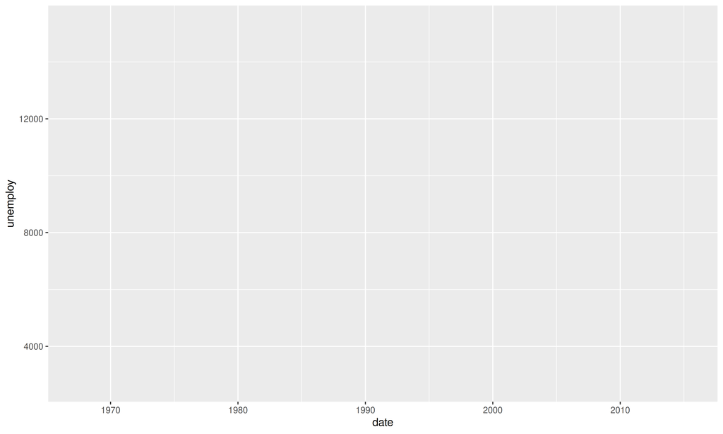

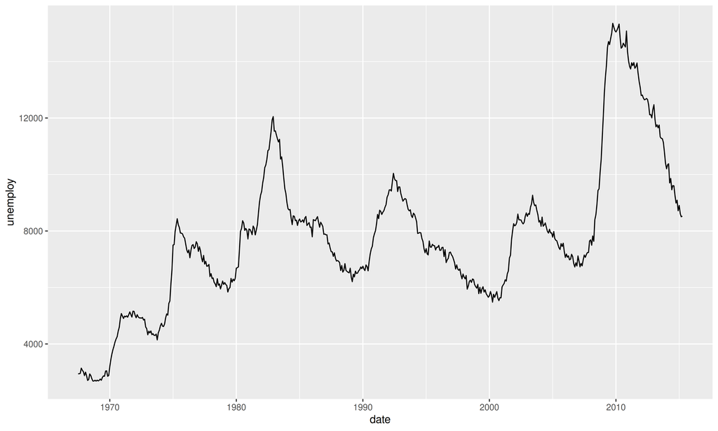

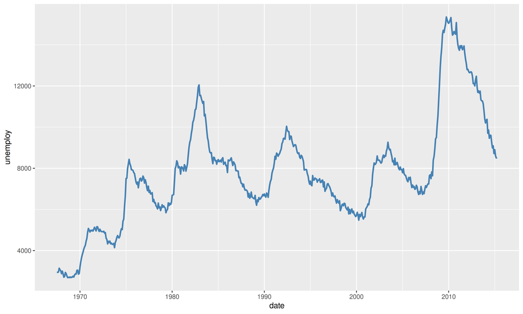

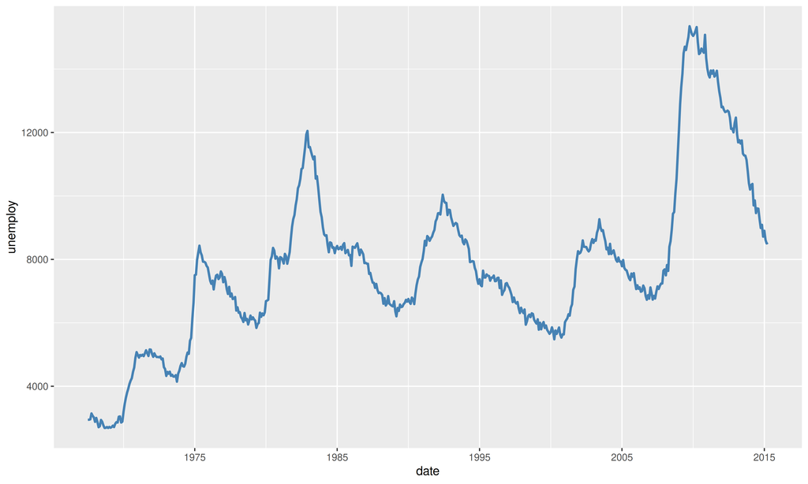

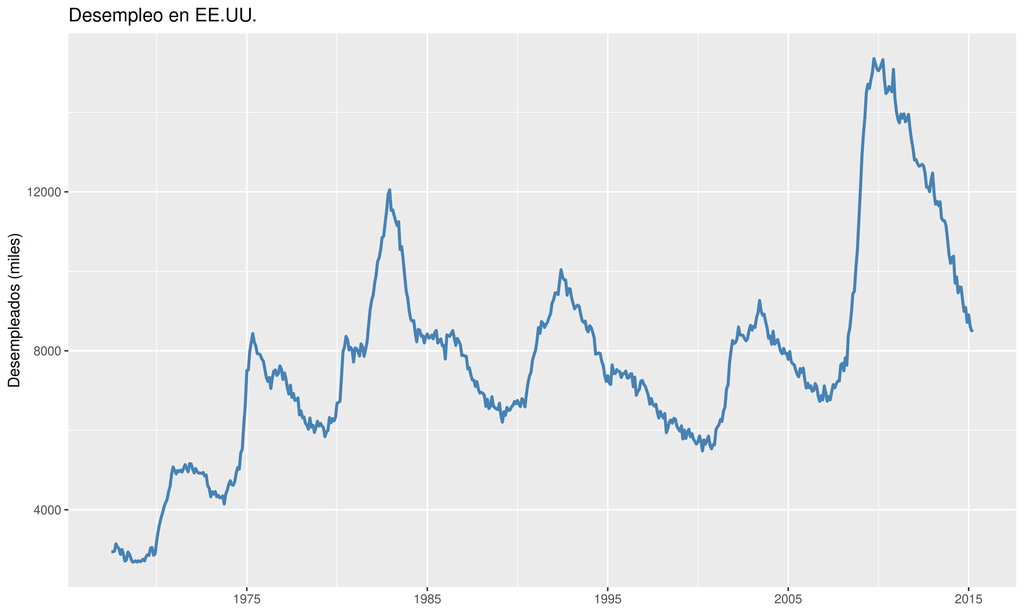

## Gráficos de líneas: ¿por qué no sale bien?

- Tarea
- Solución
- Tarea: queremos la esperanza de vida de España, Francia e Italia. ¿Por qué sale este gráfico tan raro?

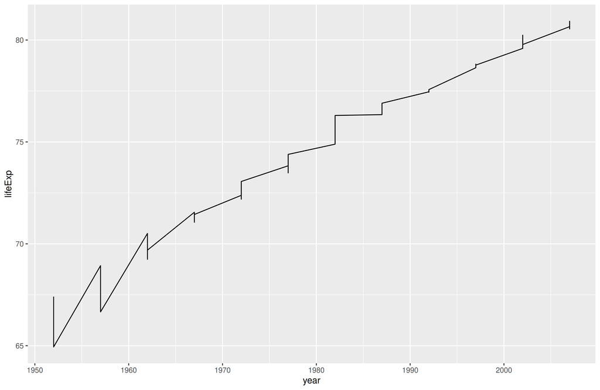

```r
df_gap <- gapminder::gapminder |>
  filter(country %in%
           c("Spain", "France", "Italy"))

ggplot(df_gap, aes(year, lifeExp)) +
  geom_line()
```

- `geom_line()` une los puntos en el orden del eje X, pero cada año hay 3 puntos (uno por país): por eso hace “zigzag”. Hay que decirle qué puntos van juntos, con `group` … o con `color`, que también agrupa

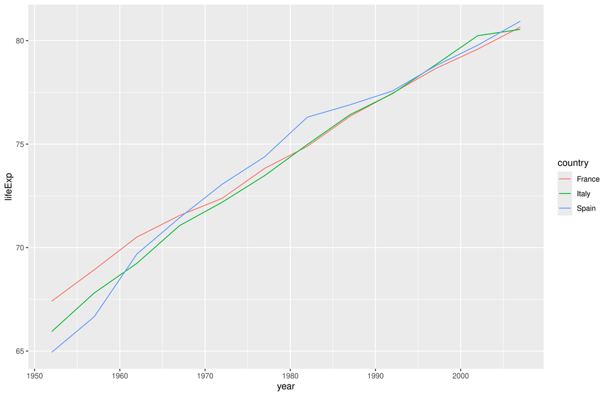

```r
ggplot(df_gap, aes(year, lifeExp,
                   group = country)) +
  geom_line()

ggplot(df_gap, aes(year, lifeExp,
                   color = country)) +
  geom_line()
```

## Gráficos de líneas: varias series

- Si los datos están en formato *largo* (una columna con el nombre de la serie y otra con su valor), basta con mapear esa columna a `color`

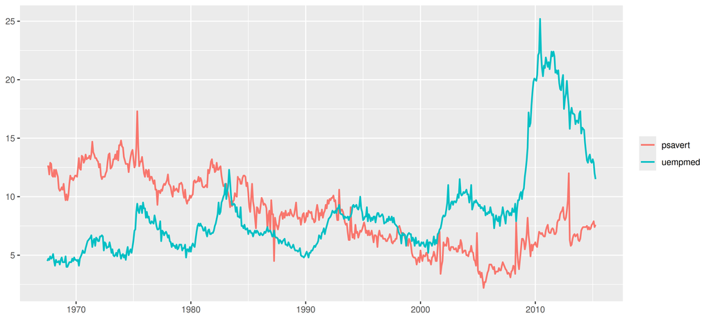

```r
economics_long |>
  filter(variable %in% c("psavert", "uempmed")) |>
  ggplot(aes(date, value, color = variable)) +
  geom_line(linewidth = 0.8) +
  labs(x = NULL, y = NULL, color = NULL)
```

## 7.6 Scatter plots (gráficos de puntos)

Muestran la relación entre dos variables continuas. Los hemos usado todo el tema, pero tienen un problema cuando hay muchos datos: el *overplotting*

## Scatter plots: el problema del *overplotting*

- Con muchas observaciones (`diamonds` tiene casi 54.000) los puntos se tapan unos a otros y no vemos dónde hay más datos. Soluciones: **transparencia** (`alpha`) o **contar puntos por zonas** (`geom_bin2d()`)

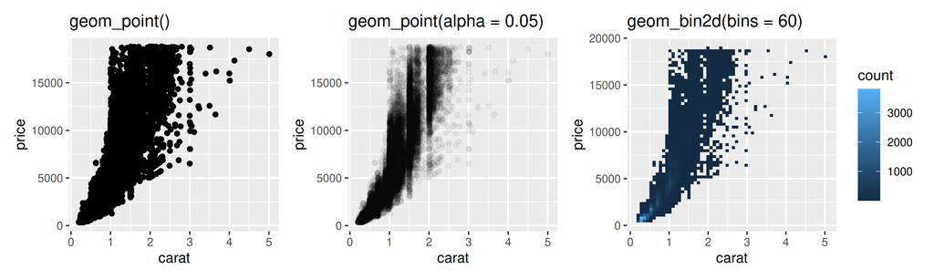

```r
ggplot(diamonds, aes(carat, price)) + geom_point()
ggplot(diamonds, aes(carat, price)) + geom_point(alpha = 0.05)
ggplot(diamonds, aes(carat, price)) + geom_bin2d(bins = 60)
```

## 8. Gráficos interactivos

Permiten al usuario interactuar con el gráfico, abriéndose posibilidades como: zooming, highlight, o mostrar información adicional al pinchar en algún elemento del gráfico, etc …

## Gráficos interactivos

- Los gráficos interactivos permiten al usuario interactuar con el gráfico
- En general, JavaScript (JS) es el lenguaje utilizado para hacer gráficos interactivos con librerías como D3, Chart.js, Plotly, vis.js, Highcharts, …
- Desde hace años, el paquete de R htmlwidgets facilita el uso de las librerías de JS en R
- Paquetes de R como leaflet, DT, dygraphs, networkD3 y muchos otros utilizan el framework de htmlwidgets para hacer disponibles los gráficos interactivos de JS en R. [[Aquí]](http://gallery.htmlwidgets.org/) puedes ver los paquetes que usan htmlwidgets
- [[Aquí]](https://www.r-graph-gallery.com/interactive-charts.html) puedes ver una galería con ejemplos

## Gráficos interactivos (**plotly**)

- Un bookdown sobre plotly: https://plotly-r.com/preface.html

```r
library(plotly)
p <- ggplot(iris, aes(Sepal.Length, Petal.Length, color = Species)) +  geom_point() + geom_smooth()
ggplotly(p)
```

[interactive chart not shown]

## Gráficos interactivos (**plotly**)

```r
p1 <- p + facet_grid(cols = vars(Species))
ggplotly(p1)
```

[interactive chart not shown]

## Gráficos interactivos (**ggiraph**)

- [ggiraph](https://davidgohel.github.io/ggiraph/) es otra opción: en lugar de `geom_point()` usamos `geom_point_interactive()` y decidimos qué se ve al pasar el ratón (`tooltip`) y qué se resalta (`data_id`)

```r
library(ggiraph)
p_g <- ggplot(iris, aes(Sepal.Length, Petal.Length, color = Species)) +
  geom_point_interactive(aes(tooltip = paste(Species, Petal.Length), data_id = Species), size = 2)

girafe(ggobj = p_g, width_svg = 8, height_svg = 3.5)
```

[interactive chart not shown]

## Otros htmlwidgets: tablas (**DT**) y mapas (**leaflet**)

- DT
- leaflet

```r
DT::datatable(iris, options = list(pageLength = 5))
```

|  | Sepal.Length | Sepal.Width | Petal.Length | Petal.Width | Species |
| --- | --- | --- | --- | --- | --- |
| 1 | 5.1 | 3.5 | 1.4 | 0.2 | setosa |
| 2 | 4.9 | 3 | 1.4 | 0.2 | setosa |
| 3 | 4.7 | 3.2 | 1.3 | 0.2 | setosa |
| 4 | 4.6 | 3.1 | 1.5 | 0.2 | setosa |
| 5 | 5 | 3.6 | 1.4 | 0.2 | setosa |
| 6 | 5.4 | 3.9 | 1.7 | 0.4 | setosa |
| 7 | 4.6 | 3.4 | 1.4 | 0.3 | setosa |
| 8 | 5 | 3.4 | 1.5 | 0.2 | setosa |
| 9 | 4.4 | 2.9 | 1.4 | 0.2 | setosa |
| 10 | 4.9 | 3.1 | 1.5 | 0.1 | setosa |

[output cut: 140 more lines]

```r
library(leaflet)
leaflet() |>
  addTiles() |>
  addMarkers(lng = -0.3425, lat = 39.4785, popup = "Facultat d'Economia (UV)")
```

[interactive chart not shown]

## Para practicar: los pingüinos de Palmer

- Tarea
- Solución 1
- Solución 2

Tarea: con los datos `penguins` (vienen con R desde la versión 4.5):

1. Haz un **boxplot** del peso (`body_mass`) para cada especie (`species`), con los puntos encima (`geom_jitter()`). ¡Que los outliers no salgan dos veces!
2. Haz un **gráfico de barras** con el número de pingüinos de cada isla (`island`), coloreando las barras según la especie

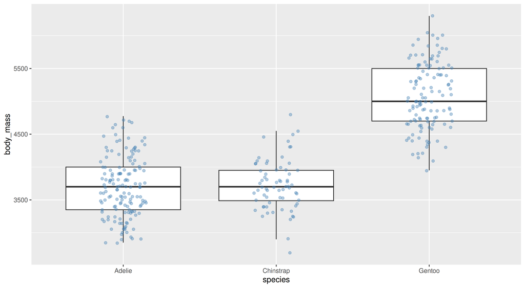

```r
ggplot(penguins, aes(species, body_mass)) +
  geom_boxplot(outlier.shape = NA) +
  geom_jitter(width = 0.15, alpha = 0.4, color = "steelblue")
```

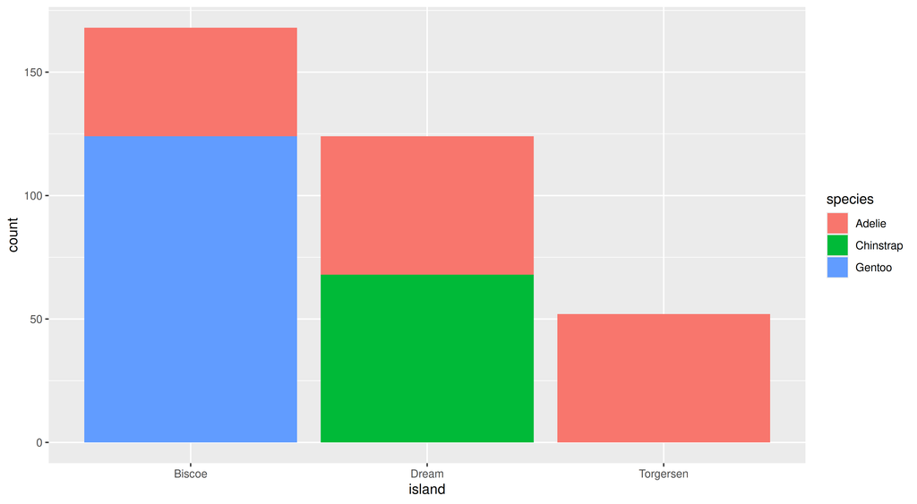

```r
ggplot(penguins, aes(island, fill = species)) +
  geom_bar()
```

## Extensiones

Algunos truquillos que se usan mucho

## Extensión: los números encima de las barras

- `geom_text()` también puede usar el stat `"count"`: así pone el recuento de cada barra, sin calcularlo antes

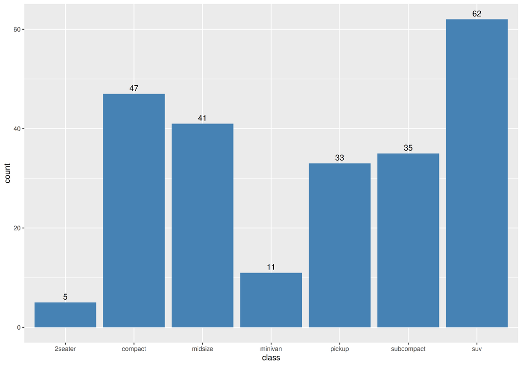

```r
ggplot(mpg, aes(x = class)) +
  geom_bar(fill = "steelblue") +
  geom_text(stat = "count",
            aes(label = after_stat(count)),
            vjust = -0.5)
```

## Extensión: la leyenda, en el subtítulo [ 🌶 ]

- Con el paquete `marquee` se pueden poner colores en los títulos: `{#color texto}`. Así el subtítulo hace de leyenda

```r
library(marquee)     #- pak::pak("marquee")
```

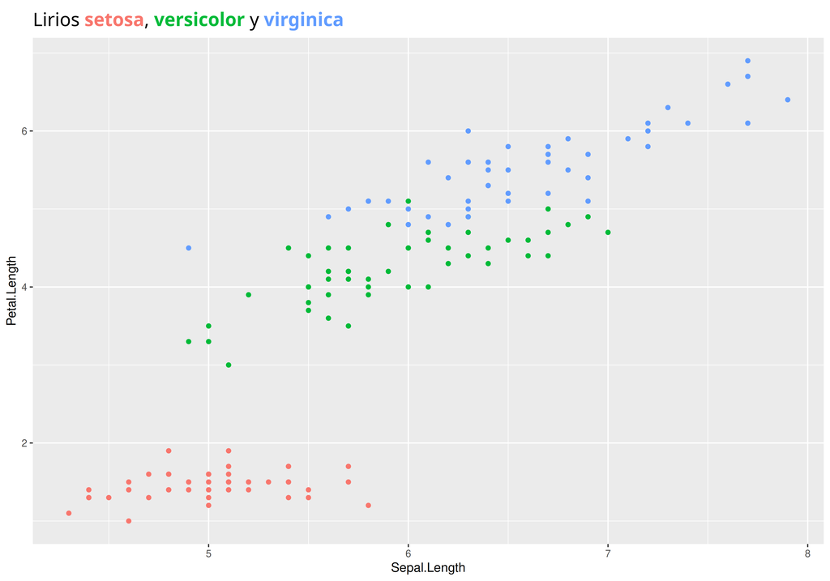

```r
ggplot(iris, aes(Sepal.Length, Petal.Length,
                 color = Species)) +
  geom_point() +
  labs(subtitle = "Lirios {#F8766D **setosa**},
                   {#00BA38 **versicolor**} y
                   {#619CFF **virginica**}") +
  theme(plot.subtitle = element_marquee(size = 16),
        legend.position = "none")
```

- Antes se hacía con el paquete `ggtext`, pero los colores había que escribirlos en HTML: `<span style='color:#F8766D;'>setosa</span>`

## Extensión: small multiples con todos los datos de fondo

- Si a una capa le quitamos la variable de los facets, esa capa sale entera en todos los paneles: sirve de fondo para comparar
- Histogramas (iris)
- Líneas (gapminder)

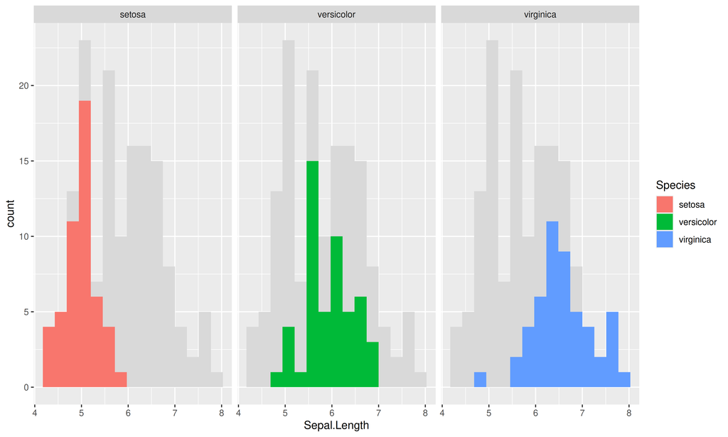

```r
iris_fondo <- iris |> select(-Species)

ggplot(iris, aes(Sepal.Length)) +
  geom_histogram(data = iris_fondo,
                 fill = "grey85", bins = 15) +
  geom_histogram(aes(fill = Species), bins = 15) +
  facet_wrap(vars(Species))
```

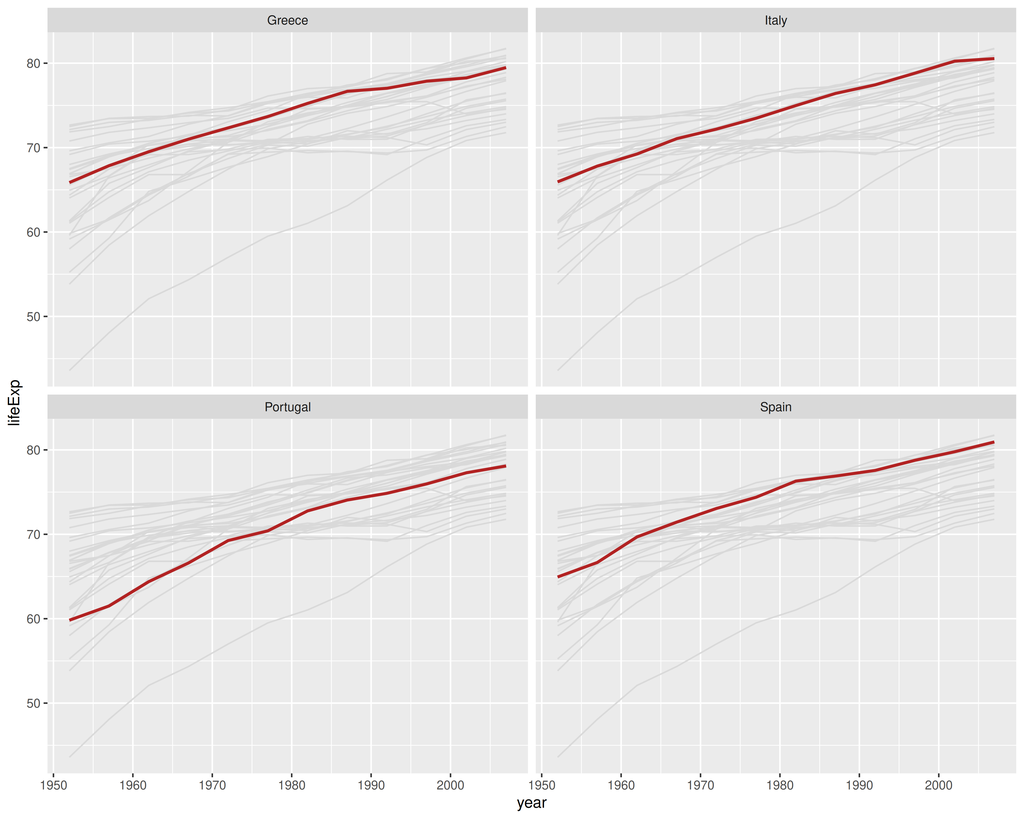

```r
europa <- gapminder::gapminder |>
  filter(continent == "Europe")
paises <- europa |>
  filter(country %in% c("Spain", "Portugal",
                        "Italy", "Greece"))
df_fondo <- europa |> rename(pais = country)

ggplot(paises, aes(year, lifeExp)) +
  geom_line(data = df_fondo, aes(group = pais),
            color = "grey85") +
  geom_line(color = "firebrick", linewidth = 1) +
  facet_wrap(vars(country))
```

- En `df_fondo` la columna se llama `pais`, no `country`: por eso sus líneas salen en todos los paneles. `group = pais` hace que haya una línea por país

## Extensión: un gráfico dentro de otro [ 🌶 ]

- Con `inset_element()` del paquete `patchwork` podemos meter un gráfico pequeño dentro de otro: por ejemplo, para enseñar un detalle o la distribución de una variable

```r
p_grande <- ggplot(iris, aes(Sepal.Length,
                             Petal.Length,
                             color = Species)) +
  geom_point()

p_peque <- ggplot(iris, aes(Petal.Length)) +
  geom_histogram(bins = 15, fill = "grey60") +
  theme_void()

p_grande +
  inset_element(p_peque,
                left = 0.55, bottom = 0.03,
                right = 0.95, top = 0.4)
```

**1**

dónde va el gráfico pequeño, de 0 a 1 (desde la esquina de abajo a la izquierda): aquí, abajo a la derecha

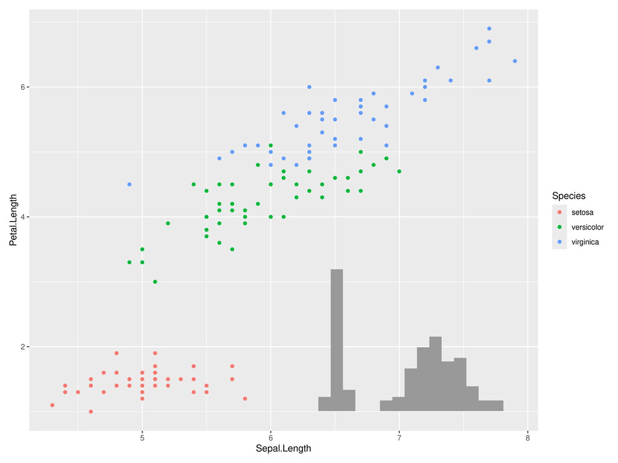

## Extensión: otro tipo de letra [ 🌶 ]

- La letra (la fuente) se cambia en el `theme()`, con `family`. Con `systemfonts` podemos usar cualquiera de [Google Fonts](https://fonts.google.com/):

```r
#- la descarga de Google Fonts y la deja lista:
systemfonts::require_font("Lobster")

p_grande +
  labs(title = "Longitud del sépalo y del pétalo") +
  theme(plot.title = element_text(family = "Lobster",
                                  size = 20))
```

- Para que se vea, el gráfico tiene que dibujarse con `ragg`.  
  En RStudio, en *Tools* → *Global Options* → *General* → *Graphics*,  
  el *Backend* tiene que ser **AGG**.  
  `ggsave()` ya lo usa (si `ragg` está instalado)
- Antes se hacía con `showtext` o `extrafont`: siguen funcionando, pero ahora se recomienda `systemfonts` + `ragg`

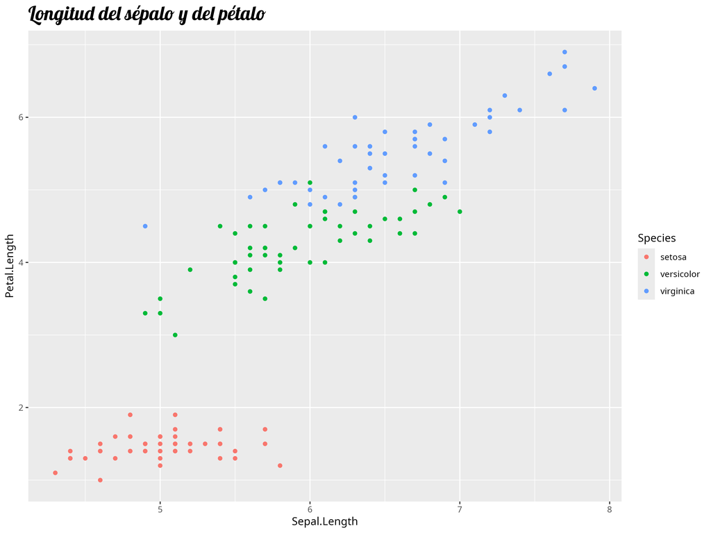